# Projeto Filtros AdFG

### Beatriz Evelbauer Simões

Nesse projeto, visamos comparar diferentes tipos de filtros com relação a diferentes ruídos em uma mesma imagem.

Os filtros propostos são o filtro do kernel da equação do calor e também o de regularização à Tikhonov, este sendo um caso particular de um filtro $ARMA(p,q)$.

Eles são definidos por:

$$\text{heat} (\lambda) = e^{- \tau \lambda}$$

onde $\tau$ é um parâmetro real a ser definido, e

$$\text{Tikhonov} (\lambda) = \frac{1}{1 + \gamma \lambda}$$

onde $\gamma$ é um parâmetro real a ser escolhido.

## Imports

```python
pip install opencv-python
```

```python
# bibliotecas
import pandas as pd
import numpy as np
import matplotlib.pyplot as plt
from pygsp import graphs, filters, plotting
from PIL import Image, ImageFilter
import scipy.sparse as sp
import cv2 # para mudar o tamanho das fotos
```

```python
# abrindo imagens
img_original = cv2.imread('cameraman_original.jpg')
img_ruido1 = cv2.imread('cameraman_ruido.jpg')
img_ruido2 = cv2.imread('cameraman_ruido2.jpg')

print("Tamanho original: ", img_original.shape[:2])
print("Tamanho ruido 1: ", img_ruido1.shape[:2])
print("Tamanho ruido 2: ", img_ruido2.shape[:2])
```

```
Tamanho original:  (256, 256)
Tamanho ruido 1:  (256, 256)
Tamanho ruido 2:  (256, 256)
```

### Reduzindo as imagens

```python
img_original = cv2.resize(img_original, (120,120))
img_ruido1 = cv2.resize(img_ruido1, (120,120))
img_ruido2 = cv2.resize(img_ruido2, (120,120))

print("Tamanho original: ", img_original.shape[:2])
print("Tamanho ruido 1: ", img_ruido1.shape[:2])
print("Tamanho ruido 2: ", img_ruido2.shape[:2])
```

```
Tamanho original:  (120, 120)
Tamanho ruido 1:  (120, 120)
Tamanho ruido 2:  (120, 120)
```

```python
# transformando em escala de cinza
img_original = cv2.cvtColor(img_original, cv2.COLOR_BGR2GRAY)
img_ruido1 = cv2.cvtColor(img_ruido1, cv2.COLOR_BGR2GRAY)
img_ruido2 =  cv2.cvtColor(img_ruido2, cv2.COLOR_BGR2GRAY)
```

```python
plt.imsave('cameraman_original_reduzido.png',Image.fromarray(img_original,'L'),cmap='gray')
```

### Transformando em sinal

```python
sinal_original = np.array(img_original).reshape(120**2)
sinal_ruido1 = np.array(img_ruido1).reshape(120**2)
sinal_ruido2 = np.array(img_ruido2).reshape(120**2)
```

## Implementação dos filtros e das métricas

Abaixo, estão definidas as funções utilizadas para calcular os filtros Heat e Tikhonov, bem como as métricas de Erro Quadrático Médio (MSE) e Peak Signal-to-Noise Ratio (PSNR).

Na ordem:

- Heat
- Tikhonov
- MSE
- PSNR

```python
def heat(lam,tau=1):
    '''Calcula a função do filtro a partir de um vetor de autovalores.

    Parâmetros:
    - lambda (array) - vetor de autovalores

    Return:
    - H (array) - matriz diagonal cujos calores da diagonal são os h(lambda_i) e
    h() é a função que define o filtro
    '''

    h_lambda = np.exp(-(tau * lam)) #h(lam,tau)
    H = np.diag(h_lambda)

    return H
```

```python
def tikhonov(lam,g=1):
    '''Calcula a matriz H da regularização à tikhonov a partir de
    um vetor de autovalores.

    Parâmetros:
    - lam (array): vetor de autovalores
    - g (float): default = 1, valor do parâmetro lambda

    Returns:
    - H (array): matriz diagonal cujas entradas são a função h()
    calculada sobre os autovalores correspondentes.'''

    h_lambda = 1/(1+ g*lam)
    H = np.diag(h_lambda)

    return H
```

```python
def MSE(original,filtrado):
    '''Calcula o erro quadrático médio da filtração escolhida.

    Parâmetros:
    - original (array): sinal original, sem ruídos, para usar como
    referência no MSE
    - filtrado (array): sinal obtido com a filtração

    Returns:
    - mse (float): erro quadrático médio'''

    soma = sum((original - filtrado)**2) # soma dos quadrados
    n = len(filtrado)
    mse = soma/n
    return mse
```

```python
def PSNR(original,filtrado,img=True):
    '''Calcula o Peak signal-to-noise ratio com relação a alguma fltração
    escolhida. O PSNR é a variação relativa do máximo valor possível
    do sinal em relação ao erro quadrático médio (norma L2 do erro),
    em escala logarítmica.

    Parâmetros:
    - original (array): sinal original
    - filtrado (array): sinal filtrado de acordo com a filtração de
    escolha

    Returns:
    - res (float): medida do PSNR'''
    mse = MSE(original,filtrado) # precisa dessa métrica
    if img:
        max_f = 255
    else:
        # definindo uma métrica alternativa para meu toy problem
        max_f = max(filtrado)
    res = 20*np.log10(max_f) - 10*np.log10(mse)
    return res
```

## Grafo Clássico

Nessa seção, vamos fazer todas as contas para os filtros implementados aqui com o grafo construído de maneira clássica, isto é, conectando os pixels adjascentes.

Além disso, vamos dividir os resultados entre os filtros Heat e Tikhonov.

```python
# primeiro a identificação das bordas
def bordas(img):
    '''Função que recupera os índices de cada uma das bordas de um array (ou imagem).

    Parâmetros:
    - img (array): matriz mxn que representa a imagem (ou qualquer outra coisa)

    Return:
    - left (list): índices da borda esquerda
    - right (list): índices da borda direita
    - up (list): índices da borda superior
    - down (list): índices da borda inferior'''
    # matriz m por n
    m, n = img.shape

    left = [i*m for i in range(n)]
    right = [i*m - 1 for i in range(1,n+1)]
    up = [i for i in range(m)]
    down = [n*(m-1) + i for i in range(m)]

    return left, right, up, down
```

```python
def grafo_img_simples(img, adj = False, plot=True):
    '''Função que retorna uma instância do objeto graph do pygsp que
    representa uma imagem. Aqui o grafo é o mais simples possível, considerando
    adjascentes os pixels vizinhos.

    Parâmetros:
     - img (array): imagem a partir da qual construiremos o grafo
     - adj (Bool): default = False, indica se retornamos ou não a matriz de adjascência
      do grafo criado
     - plot (Bool): default = True, faz o desenho do grafo
    '''
    # primeira coisa é pegar as bordas
    left, right, up, down = bordas(img)
    m,n = img.shape
    #W = np.zeros((m*n,m*n))
    W = []

    for i in range(m*n):
        linha = np.zeros(m*n,dtype=np.int16)

        if i == 0: # canto superior esquerdo
            linha[1] = 1 # a direita
            linha[m] = 1 # abaixo
            linha[m+1] = 1 # diagonal p baixo

        elif i == m-1: # canto superior direito
            linha[i-1] = 1 # a esquerda
            linha[i+m] = 1 # abaixo
            linha[i+m-1] = 1 # diagonal p baixo

        elif i == n*(m-1): # canto inferior esquerdo
            linha[i+1] = 1 # a direita
            linha[i-m] = 1 # acima
            linha[i-m+1] = 1

        elif i == n*m -1: # canto inferior direito
            linha[i-1] = 1 # a esquerda
            linha[i-m] = 1 # acima
            linha[i-m-1] = 1

        elif i in up:
           linha[i-1] = 1
           linha[i+1] = 1
           linha[i+m] = 1
           linha[i+m-1] = 1
           linha[i+m+1] = 1

        elif i in left:
            linha[i+1] = 1
            linha[i-m] = 1
            linha[i+m] = 1
            linha[i-m+1] = 1
            linha[i+m+1] = 1

        elif i in right:
            linha[i-m] = 1
            linha[i+m] = 1
            linha[i-1] = 1
            linha[i-m-1] =1
            linha[i+m-1] = 1

        elif i in down:
            linha[i-1] - 1
            linha[i+1] = 1
            linha[i-m] = 1
            linha[i-m+1] = 1
            linha[i-m-1] = 1

        else:
            linha[i-m-1] = 1
            linha[i-m] = 1
            linha[i-m+1] = 1
            linha[i-1] = 1
            linha[i+1] = 1
            linha[i+m-1] = 1
            linha[i+m] = 1
            linha[i+m+1] = 1

        W.append(linha)
    W = sp.csc_matrix(np.array(W, dtype=np.int16))
    #assert W.shape == (m*n,m*n)

    # criando o grafo
    G = graphs.Graph(W)

    if adj:
        return G, W
    elif plot:
        G.set_coordinates()
        G.plot(title=f"Grafo trivial para imagem {m}x{n}")
        return G
    else:
        return G
```

Note que essa construção independe do sinal, então vamos fazê-la a partir da imagem original e computar somente os filtros a partir das imagens com ruido.

```python
G_classico = grafo_img_simples(img_original, False, False)
```

### Heat

```python
# calculando autofunções
G_classico.compute_fourier_basis()

U = G_classico.U # autofunções
lam = G_classico.e # autovalores

aux1 = U.T @ sinal_ruido1
aux2 = U.T @ sinal_ruido2
```

```
2024-06-26 18:44:18,803:[WARNING](pygsp.graphs.graph.compute_fourier_basis): Computing the full eigendecomposition of a large matrix (14400 x 14400) may take some time.
```

```python
# calculando para parametros dentro de [epsilon,1] para ver qual é o melhor
tau = np.linspace(1e-4,1,100)

heat_ruido1, heat_ruido2 = [], []
mse_heat1, mse_heat2, psnr_heat1, psnr_heat2 = [], [], [], []

for t in tau:
    r1 = U @ heat(lam, tau = t) @ aux1
    r2 = U @ heat(lam, tau = t) @ aux2

    # guardando resultados
    heat_ruido1.append(np.round(r1))
    heat_ruido2.append(np.round(r2))

    # metricas de erro
    mse_heat1.append(MSE(sinal_original,r1))
    mse_heat2.append(MSE(sinal_original,r2))
    psnr_heat1.append(PSNR(sinal_original,r1))
    psnr_heat2.append(PSNR(sinal_original,r2))
```

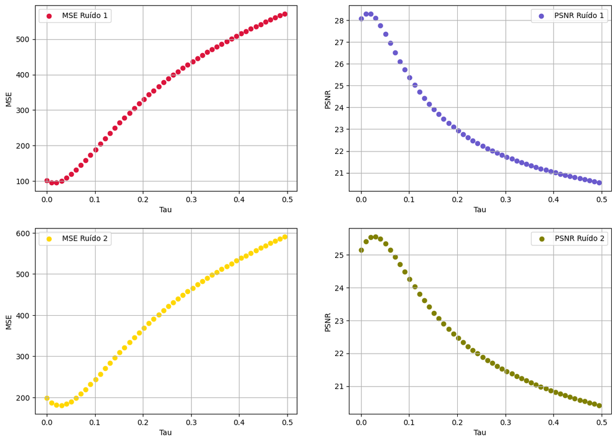

```python
fig, ax = plt.subplots(figsize = (14,10), ncols = 2, nrows = 2)

ax[0,0].scatter(tau[:50], mse_heat1[:50], label = "MSE Ruído 1", color = "crimson")
ax[0,0].legend()
ax[0,0].set_xlabel("Tau")
ax[0,0].set_ylabel("MSE")
ax[0,0].grid()

ax[0,1].scatter(tau[:50], psnr_heat1[:50], label = "PSNR Ruído 1", color = "slateblue")
ax[0,1].legend()
ax[0,1].set_xlabel("Tau")
ax[0,1].set_ylabel("PSNR")
ax[0,1].grid()

ax[1,0].scatter(tau[:50],mse_heat2[:50], label = "MSE Ruído 2", color = "gold")
ax[1,0].legend()
ax[1,0].set_xlabel("Tau")
ax[1,0].set_ylabel("MSE")
ax[1,0].grid()

ax[1,1].scatter(tau[:50],psnr_heat2[:50], label = "PSNR Ruído 2", color = "olive")
ax[1,1].legend()
ax[1,1].set_xlabel("Tau")
ax[1,1].set_ylabel("PSNR")
ax[1,1].grid()
```

```python
# selecionando os parâmetros
ind1 = np.argmin(np.array(mse_heat1))
ind2 = np.argmin(np.array(mse_heat2))

tau1 = tau[ind1]
tau2 = tau[ind2]

heat_ruido1_otimo = heat_ruido1[ind1]
heat_ruido2_otimo = heat_ruido2[ind2]
```

A fim de comparação, indicamos abaixo os índices dos valors de $\tau$ que minimizam o MSE e maximizam o PSNR, respectivamente.

Note que utilizamos o `argmax` para o PSNR porque ele é minimiado sempre quando o parâmetro aumenta, pois quanto maior o parâmetro mais suavizado fica o sinal.

```python
print("MSE 1)",ind1,"MSE2)", ind2,"PSNR 1)", np.argmax(np.array(psnr_heat1)),"PSNR 2)", np.argmax(np.array(psnr_heat2)))
```

```
MSE 1) 1 MSE2) 3 PSNR 1) 1 PSNR 2) 3
```

### Tikhonov

```python
gamas = np.linspace(1e-6,2,50)

tik_ruido1, tik_ruido2 = [], []
mse_tik1, mse_tik2, psnr_tik1, psnr_tik2 = [], [], [], []

for t in gamas:
    r1 = U @ tikhonov(lam, g = t) @ aux1
    r2 = U @ tikhonov(lam, g = t) @ aux2

    # guardando resultados
    tik_ruido1.append(np.round(r1))
    tik_ruido2.append(np.round(r2))

    # metricas de erro
    mse_tik1.append(MSE(sinal_original,r1))
    mse_tik2.append(MSE(sinal_original,r2))
    psnr_tik1.append(PSNR(sinal_original,r1))
    psnr_tik2.append(PSNR(sinal_original,r2))
```

[figure not shown]

```python
fig, ax = plt.subplots(figsize = (14,10), ncols = 2, nrows = 2)

ax[0,0].scatter(gamas, mse_tik1, label = "MSE Ruído 1", color = 'crimson')
ax[0,0].set_xlabel("Gammas")
ax[0,0].set_ylabel("MSE")
ax[0,0].grid()
ax[0,0].legend()

ax[0,1].scatter(gamas, psnr_tik1, label = "PSNR Ruído 1", color = 'slateblue')
ax[0,1].set_xlabel("Gammas")
ax[0,1].set_ylabel("PSNR")
ax[0,1].grid()
ax[0,1].legend()

ax[1,0].scatter(gamas,mse_tik2, label = "MSE Ruído 2", color = 'gold')
ax[1,0].set_xlabel("Gammas")
ax[1,0].set_ylabel("MSE")
ax[1,0].grid()
ax[1,0].legend()

ax[1,1].scatter(gamas,psnr_tik2, label = "PSNR Ruído 2", color = 'olive')
ax[1,1].set_xlabel("Gammas")
ax[1,1].set_ylabel("PSNR")
ax[1,1].grid()
ax[1,1].legend()
```

```python
# selecionando os parâmetros
ind1_t = np.argmin(np.array(mse_tik1))
ind2_t = np.argmin(np.array(mse_tik2))

gama1 = gamas[ind1_t]
gamas2 = tau[ind2_t]

tik_ruido1_otimo = tik_ruido1[ind1_t]
tik_ruido2_otimo = tik_ruido2[ind2_t]
```

```python
print("MSE 1)",ind1_t,"MSE2)", ind2_t,"PSNR 1)", np.argmax(np.array(psnr_tik1)),"PSNR 2)", np.argmax(np.array(psnr_tik2)))
```

```
MSE 1) 0 MSE2) 1 PSNR 1) 0 PSNR 2) 1
```

### Resultados

Primeiro vamos comparar os resultados numéricos e depois a olho nu.

```python
labels = [f"Heat Ótimo {tau[ind1]}", f"Tikhonov Ótimo ({gamas[ind1_t]})"]
resultados = pd.DataFrame(data = np.array([labels,
                                            [mse_heat1[ind1], mse_tik1[ind1_t]],
                                            [mse_heat2[ind2], mse_tik2[ind2_t]],
                                            [psnr_heat1[ind1], psnr_tik1[ind1_t]],
                                            [psnr_heat2[ind2], psnr_tik2[ind2_t]]]).T,
                            columns = ['Método','MSE Ruído 1', 'MSE Ruído 2', 'PSNR Ruído 1','PSNR Ruído 2'])
resultados
```

|  | Método | MSE Ruído 1 | MSE Ruído 2 | PSNR Ruído 1 | PSNR Ruído 2 |
| --- | --- | --- | --- | --- | --- |
| 0 | Heat Ótimo 0.010199999999999999 | 96.13432628912464 | 180.9036620647914 | 28.302018737600786 | 25.556330024191876 |
| 1 | Tikhonov Ótimo (1e-06) | 101.63641856034351 | 181.7897113827877 | 28.06031007784385 | 25.535110607285162 |

Além disso, note que o erro quadrático médio dos filtros heat é bem maior para tratar o ruído 2.

```python
# salvando as imagens
# ruido 1
plt.imsave('cameraman_CR1H.png', heat_ruido1[ind1].reshape((120,120)), cmap='gray')

# tikhonov
plt.imsave('cameraman_CR1TIK.png', tik_ruido1[ind1_t].reshape((120,120)), cmap='gray')

# ruido 2
plt.imsave('cameraman_CR2H.png', heat_ruido2[ind2].reshape((120,120)), cmap='gray')

# tikhonov
plt.imsave('cameraman_CR2TIK.png', tik_ruido2[ind2_t].reshape((120,120)), cmap='gray')
```

#### Ruido 1

[output not shown]

#### Ruido 2

[output not shown]

Podemos concluir que o filtro heat com parâmetro $\tau=0.01$ se saiu melhor na comparação a olho nu, possivelmente por ser o menos homogenizador dos filtros, i.e., preserva as diferenças de tonalidade entre vértices adjascentes.

## Grafo com Pesos

Nessa seção, introduzimos um novo método para construção dos grafos, em que é aplicado um peso Gaussiano quando dois vértices são $\kappa$-próximos, ou seja,

$$a_{ij} = e^{- d^2 / 2 \sigma^2}, \text{se} |d(i,j)| < \kappa$$

A distância aqui utilizada é a diferença entre as cores de cada pixel em grayscale.

```python
def grafo_peso_grayscale(img,th,kap,adj=False,plot=True):
    '''Função que constrói o grafo para uma imagem em escala de cinzas
    a partir do gradiente de cor. Os pesos atribuidos a cada vértice serão
    uma gaussiana de variância theta^2 avaliada em em x = gray(i) - gray(j),
     onde gray() é o valor na escala de cinzas de cada pixel.

    Parâmetros:
     - img (array): matrix representando a imagem, suas entradas correspondem ao valor
     de cada vértice na escala de cinza
     - th (float): desvio padrão da Gaussiana
     - kap (float): threshold de conexão dos vértices'''

    m,n = img.shape
    img_array = np.array(img).reshape(n*m)
    N = m*n
    W = np.zeros((N,N))
    #W = sp.coo_matrix(shape=(N,N),dtype=np.float16)
    for i in range(N):
        for j in range(N):
            dist = abs(img_array[i] - img_array[j])
            #print(img[ij,ii],img[jj,ji],dist)
            if dist < kap and i!=j:
                W[i,j] = np.exp(-((dist*dist)/(2*th*th)), dtype=np.float32)
                #print(W[i,j])
                assert W[i,j] <= 1

    G = graphs.Graph(W)
    if adj:
        return G, W
    elif plot:
        G.set_coordinates()
        G.plot(title=f"Grafo com pesos $\kappa =$ {kap}")
        return G
    else:
        return G
```

Diferentemente do primeiro grafo, essa construção depende do valor do sinal para calcular as distâncias entre os vértices, então temos um grafo para cada ruído diferente.

```python
G_ruido1_peso = grafo_peso_grayscale(img_ruido1, 1, 5, False,False)
G_ruido2_peso = grafo_peso_grayscale(img_ruido2, 1, 5, False,False)
```

```python
G_ruido1_peso.compute_fourier_basis()
G_ruido1_peso.e[0] = 0
```

```
2024-06-28 09:40:54,180:[WARNING](pygsp.graphs.graph.compute_fourier_basis): Computing the full eigendecomposition of a large matrix (14400 x 14400) may take some time.
```

```python
G_ruido2_peso.compute_fourier_basis()
G_ruido2_peso.e[0] = 0
```

```
2024-06-28 09:54:01,116:[WARNING](pygsp.graphs.graph.compute_fourier_basis): Computing the full eigendecomposition of a large matrix (14400 x 14400) may take some time.
```

```python
U_peso1 = G_ruido1_peso.U
lam1 = G_ruido1_peso.e

U_peso2 = G_ruido2_peso.U
lam2 = G_ruido2_peso.e

aux1 = U_peso1.T @ sinal_ruido1
aux2 = U_peso2.T @ sinal_ruido2
```

### Heat

```python
# calculando para parametros dentro de [epsilon,1] para ver qual é o melhor
tau = np.linspace(1e-4,1,50)

heat_peso1 = [] # resultados da filtração
heat_peso2 = []

# listas para guardar as métricas de erro
mse_peso1, mse_peso2 = [], []
psnr_peso1, psnr_peso2 = [], []
for t in tau:
    # calculando o sinal filtrado
    r1 = U_peso1 @ heat(lam1, tau = t) @ aux1
    r2 = U_peso2 @ heat(lam2, tau = t) @ aux2

    # guardando resultados
    heat_peso1.append(np.round(r1))
    heat_peso2.append(np.round(r2))

    # metricas de erro
    mse_peso1.append(MSE(sinal_original,r1))
    mse_peso2.append(MSE(sinal_original,r2))
    psnr_peso1.append(PSNR(sinal_original,r1))
    psnr_peso2.append(PSNR(sinal_original,r2))
```

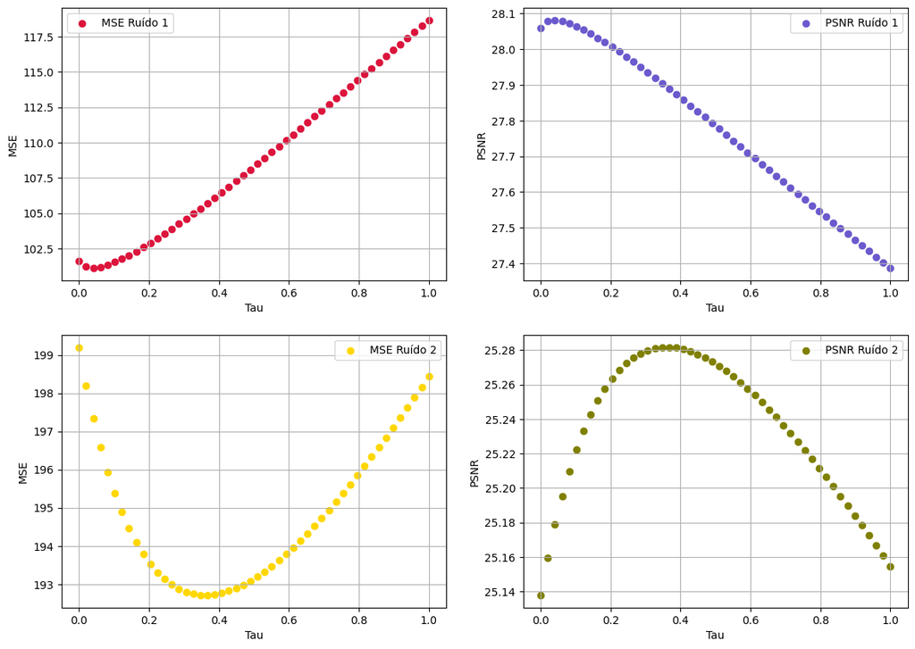

```python
fig, ax = plt.subplots(figsize = (14,10), ncols = 2, nrows = 2)

ax[0,0].scatter(tau, mse_peso1, label = "MSE Ruído 1", color = "crimson")
ax[0,0].set_xlabel("Tau")
ax[0,0].set_ylabel("MSE")
ax[0,0].grid()
ax[0,0].legend()

ax[0,1].scatter(tau, psnr_peso1, label = "PSNR Ruído 1", color = "slateblue")
ax[0,1].set_xlabel("Tau")
ax[0,1].set_ylabel("PSNR")
ax[0,1].grid()
ax[0,1].legend()

ax[1,0].scatter(tau,mse_peso2, label = "MSE Ruído 2", color = "gold")
ax[1,0].set_xlabel("Tau")
ax[1,0].set_ylabel("MSE")
ax[1,0].grid()
ax[1,0].legend()

ax[1,1].scatter(tau,psnr_peso2, label = "PSNR Ruído 2", color = "olive")
ax[1,1].set_xlabel("Tau")
ax[1,1].set_ylabel("PSNR")
ax[1,1].grid()
ax[1,1].legend()
```

```python
# selecionando os parâmetros
ind1p = np.argmin(np.array(mse_peso1))
ind2p = np.argmin(np.array(mse_peso2))

tau1 = tau[ind1p]
tau2 = tau[ind2p]

heat_peso1_otimo = heat_peso1[ind1p]
heat_peso2_otimo = heat_peso2[ind2p]
```

```python
print("MSE 1)",ind1p,"MSE2)", ind2p,"PSNR 1)", np.argmax(np.array(psnr_peso1)),"PSNR 2)", np.argmax(np.array(psnr_peso2)))
```

```
MSE 1) 2 MSE2) 18 PSNR 1) 2 PSNR 2) 18
```

```python
print("Tau 1: ", tau1, "Tau 2: ", tau2)
```

```
Tau 1:  0.04091224489795919 Tau 2:  0.36741020408163266
```

### Tikhonov

```python
gamas = np.linspace(1e-5,10,50)

tik_peso1, tik_peso2 = [], []
mse_tik_peso1, mse_tik_peso2, psnr_tik_peso1, psnr_tik_peso2 = [], [], [], []

for t in gamas:
    r1 = U_peso1 @ tikhonov(lam, g = t) @ aux1
    r2 = U_peso2 @ tikhonov(lam, g = t) @ aux2

    # guardando resultados
    tik_peso1.append(np.round(r1))
    tik_peso2.append(np.round(r2))

    # metricas de erro
    mse_tik_peso1.append(MSE(sinal_original,r1))
    mse_tik_peso2.append(MSE(sinal_original,r2))
    psnr_tik_peso1.append(PSNR(sinal_original,r1))
    psnr_tik_peso2.append(PSNR(sinal_original,r2))
```

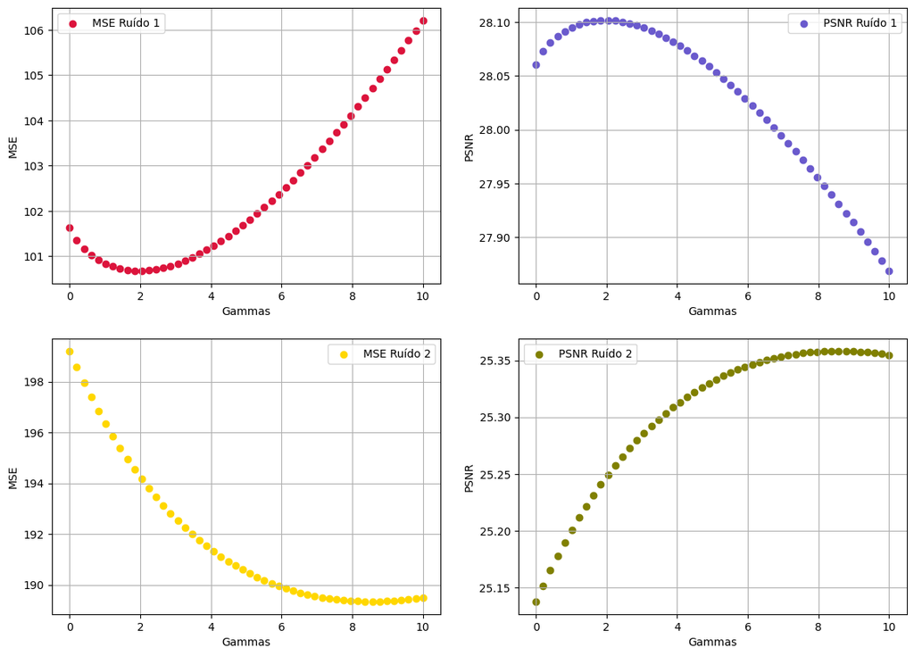

```python
fig, ax = plt.subplots(figsize = (14,10), ncols = 2, nrows = 2)

ax[0,0].scatter(gamas, mse_tik_peso1, label = "MSE Ruído 1", color = "crimson")
ax[0,0].set_xlabel("Gammas")
ax[0,0].set_ylabel("MSE")
ax[0,0].grid()
ax[0,0].legend()

ax[0,1].scatter(gamas, psnr_tik_peso1, label = "PSNR Ruído 1", color = "slateblue")
ax[0,1].set_xlabel("Gammas")
ax[0,1].set_ylabel("PSNR")
ax[0,1].grid()
ax[0,1].legend()

ax[1,0].scatter(gamas,mse_tik_peso2, label = "MSE Ruído 2", color = "gold")
ax[1,0].set_xlabel("Gammas")
ax[1,0].set_ylabel("MSE")
ax[1,0].grid()
ax[1,0].legend()

ax[1,1].scatter(gamas,psnr_tik_peso2, label = "PSNR Ruído 2", color = "olive")
ax[1,1].set_xlabel("Gammas")
ax[1,1].set_ylabel("PSNR")
ax[1,1].grid()
ax[1,1].legend()
```

```python
# selecionando os parâmetros
ind1_tp = np.argmin(np.array(mse_tik_peso1))
ind2_tp = np.argmin(np.array(mse_tik_peso2))

gama1 = gamas[ind1_tp]
gama2 = gamas[ind2_tp]

tik_peso1_otimo = tik_peso1[ind1_tp]
tik_peso2_otimo = tik_peso2[ind2_tp]
```

```python
print("MSE 1)",ind1_tp,"MSE2)", ind2_tp,"PSNR 1)", np.argmax(np.array(psnr_tik_peso1)),"PSNR 2)", np.argmax(np.array(psnr_tik_peso2)))
```

```
MSE 1) 10 MSE2) 42 PSNR 1) 10 PSNR 2) 42
```

```python
print("Gamma 1: ", gama1, "Gamma 2: ", gama2)
```

```
Gamma 1:  2.0408242857142858 Gamma 2:  8.57143
```

### Resultados

Como no caso anterior, vamos fazer os resultados numéricos primeiro.

```python
labels = [f'Heat ótimo', 'Tikhonov ótimo']
resultados = pd.DataFrame(data = np.array([labels,
                                            [mse_heat1[ind1p], mse_tik1[ind1_tp]],
                                            [mse_heat2[ind2p], mse_tik2[ind2_tp]],
                                            [psnr_heat1[ind1p], psnr_tik1[ind1_tp]],
                                            [psnr_heat2[ind2p], psnr_tik2[ind2_tp]]]).T,
                            columns = ['Método','MSE Ruído 1','MSE Ruído 2','PSNR Ruído 1','PSNR Ruído 2'])
resultados
```

[output not shown]

Agora, a comparação a olho nu.

```python
# salvando as imagens
# ruido 1
plt.imsave('cameraman_PR1H.png', heat_peso1_otimo.reshape((120,120)), cmap='gray')

# tikhonov
plt.imsave('cameraman_PR1TIK.png', tik_peso1_otimo.reshape((120,120)), cmap='gray')

# ruido 2
plt.imsave('cameraman_PR2H.png', heat_peso2_otimo.reshape((120,120)), cmap='gray')

# tikhonov
plt.imsave('cameraman_PR2TIK.png', tik_peso2_otimo.reshape((120,120)), cmap='gray')
```

#### Ruido 1 - Pesos

[output not shown]

#### Ruido 2 - Pesos

[output not shown]

Note que, comparado aos resultado com o grafo clássico, as imagens são muito parecidas para diferentes filtrações, possivelmente porque a construção desse grafo já separa bem os vértices com tonalidades mais distantes, não havendo a suavização do sinal entre eles quando não são adjascentes.

Ainda assim, podemos ver que para o caso do ruído 2, tanto o filtro Heat quanto Tikhonov não conseguiram filtrar muito bem o ruído no fundo da imagem.

Para o caso do ruído 1 os resultados são melhores e bem mais similares.

## Comparação com o PyGSP

Como o filtro de regularização à Tikhonov não é implementado em nenhum método do PyGSP, vamos comparar apenas com o filtro heat.

Como o `compute_fourier_basis` é comum aos dois métodos, basta calcular $Uh(\lambda)U^T x$, onde:

- $U$ é a matriz de autovetores de $L$
- $h(\lambda)$ é a função que define o filtro aplicada aos autovalores
- $x$ é o sinal

### Ruido 1

```python
%%timeit
U @ heat(lam, tau = 1) @ U.T @ sinal_ruido1
```

```
1min 16s ± 1.68 s per loop (mean ± std. dev. of 7 runs, 1 loop each)
```

```python
%%timeit
U_peso1 @ heat(lam1, tau = 1) @ U_peso1.T @ sinal_ruido1
```

```
5min 45s ± 890 ms per loop (mean ± std. dev. of 7 runs, 1 loop each)
```

```python
%%timeit
filters.Heat(G_classico,1).filter(sinal_ruido1,method='exact')
```

```
873 ms ± 65.2 ms per loop (mean ± std. dev. of 7 runs, 1 loop each)
```

### Ruido 2

```python
%%timeit
U @ heat(lam, tau = 1) @ U.T @ sinal_ruido2
```

```
1min 14s ± 164 ms per loop (mean ± std. dev. of 7 runs, 1 loop each)
```

```python
%%timeit
U_peso2 @ heat(lam2, tau = 1)  @ U_peso2.T @ sinal_ruido2
```

```
1min 14s ± 195 ms per loop (mean ± std. dev. of 7 runs, 1 loop each)
```

```python
%%timeit
filters.Heat(G_classico,1).filter(sinal_ruido2,method='exact')
```

```
827 ms ± 26.3 ms per loop (mean ± std. dev. of 7 runs, 1 loop each)
```

### Resultados

Vemos, claramente, que o método de filtro do PyGSP é mais otimizado.